# Tareas a realizar

1. Crea cada gráfico con Matplotlib de la forma más completa posible, añadiendo nombres de ejes, títulos, leyenda, etc. en función de los apuntes o lo que investigues por tu cuenta. Si usas una función o parámetro no visto en los apuntes, documéntala en el código con comentarios de línea.
2. Una vez hecho el gráfico con Matplotlib, con ayuda de tu IA de confianza, pide que te covierta el gráfico a otro equivalente, pero más estiloso, usando la librería Seaborn. Documenta en el código para qué sirve cada función y parámetro usado en esta versión.

Cuando solamente se pide una gráfica puedes usar el enfoque orientado a función o invocar a subplots y trabajar a partir de ax.

# Gráfica 1

Del fichero **lifeExpectancyAtBirth.cs** muestra en un gráfico de línea la evolución de España, siendo el eje Y la esperanza de vida, el eje X el año de medición.

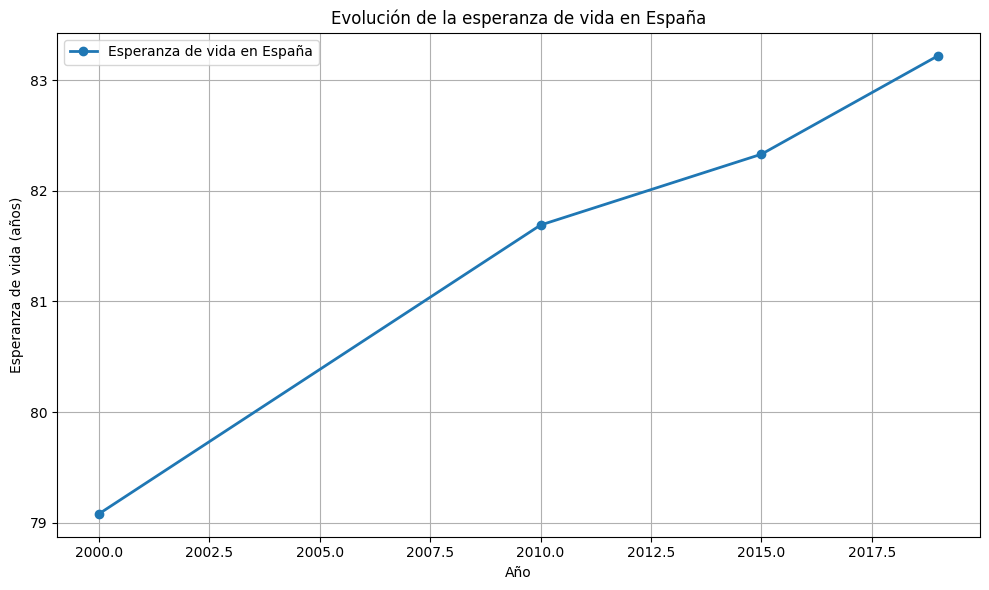

```python
import pandas as pd
import matplotlib.pyplot as plt

# Cargar los datos desde el archivo CSV
data = pd.read_csv('lifeExpectancyAtBirth.csv')

# Filtrar los datos para España
# Filtrar España y total
spain_data = data[
    (data['Location'] == 'Spain') &
    (data['Dim1'] == 'Both sexes')
]

# Crear figura y ejes (enfoque orientado a objetos)
fig, ax = plt.subplots(figsize=(10, 6))

# Dibujar la línea
ax.plot(
    spain_data['Period'],
    spain_data['First Tooltip'],
    marker='o',
    linewidth=2,        # Grosor de la línea
    label='Esperanza de vida en España'
)

# Añadir títulos y etiquetas
ax.set_title('Evolución de la esperanza de vida en España')
ax.set_xlabel('Año')
ax.set_ylabel('Esperanza de vida (años)')

# Mostrar leyenda y rejilla
ax.legend()
ax.grid(True)

# Ajusta automáticamente los márgenes
plt.tight_layout()
plt.show()
```

# Gráfica 2

Del fichero **paises.csv**. Muestra en un gráfico de tarta el PIB de los paises de Europa, pero solamente los 10 paises con mayor PIB. Hazlo de manera que se vea también el % del PIB en el gráfico.

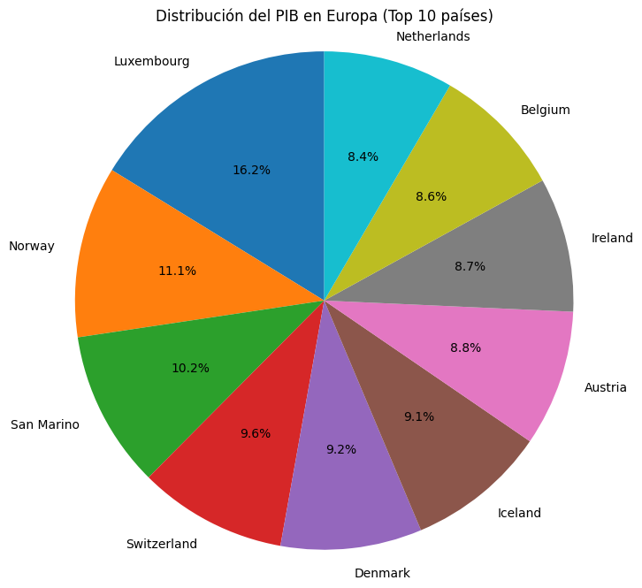

```python
import pandas as pd
import matplotlib.pyplot as plt

# Cargar los datos del fichero CSV
data = pd.read_csv('paises.csv')

# Filtrar solo los países de Europa
europa = data[data['continente'] == 'Europe']

# Ordenar por PIB de mayor a menor
europa_top10 = europa.sort_values(by='PIB', ascending=False).head(10)

# Crear el gráfico de tarta
plt.figure(figsize=(8, 8))

plt.pie(
    europa_top10['PIB'],              # Valores numéricos (PIB)
    labels=europa_top10['pais'],      # Etiquetas de cada porción
    autopct='%1.1f%%',                # Muestra el porcentaje con 1 decimal
    startangle=90                     # Gira el gráfico para mejor visualización
)

# Título del gráfico
plt.title('Distribución del PIB en Europa (Top 10 países)')

# Hace que el gráfico sea un círculo perfecto
plt.axis('equal')

plt.show()
```

# Gráfica 3.

Haz lo mismo que en el gráfico 2 pero a nivel mundial, agrupando por Continente.

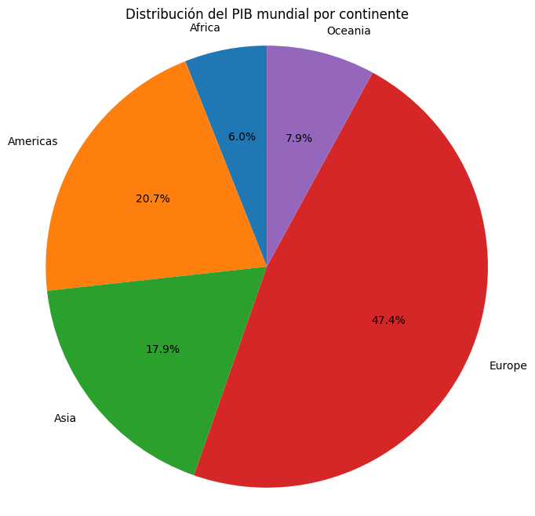

```python
import pandas as pd
import matplotlib.pyplot as plt

# Cargar los datos del fichero CSV
data = pd.read_csv('paises.csv')

# Agrupar por continente y sumar el PIB
pib_continentes = (
    data
    .groupby('continente', as_index=False)['PIB']
    .sum()
)

# Crear el gráfico de tarta
plt.figure(figsize=(8, 8))

plt.pie(
    pib_continentes['PIB'],           # Valores numéricos (PIB total)
    labels=pib_continentes['continente'],  # Etiquetas (continentes)
    autopct='%1.1f%%',                # Porcentaje con un decimal
    startangle=90                     # Mejor orientación visual
)

# Título del gráfico
plt.title('Distribución del PIB mundial por continente')

# Asegura que el gráfico sea circular
plt.axis('equal')

plt.show()
```

# Gráfica 4.

1. De la unión interna de paises.csv y médicos.csv, agrupando por región, haz una nube de puntos con el PIB en el eje X y la cantidad de médicos en el eje Y.
2. Calcula la media mundial de médicos y del PIB.
3. Pinta sobre la gráfica el punto medio de cada eje, de otro color. Incluye la leyenda.

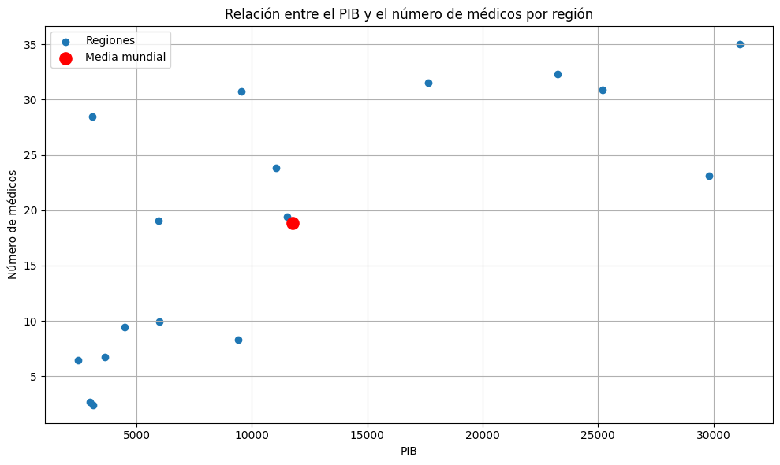

```python
import pandas as pd
import matplotlib.pyplot as plt

# Cargar los datos
paises = pd.read_csv('paises.csv')
medicos = pd.read_csv('medicos.csv')

# Renombrar columnas para facilitar el trabajo
medicos = medicos.rename(columns={
    'Location': 'pais',
    'First Tooltip': 'medicos'
})

# Unión interna entre países y médicos
datos = pd.merge(
    paises,
    medicos,
    on='pais',
    how='inner'
)

# Agrupar por región y calcular la media de PIB y médicos
datos_region = (
    datos
    .groupby('region', as_index=False)
    .agg({
        'PIB': 'mean',
        'medicos': 'mean'
    })
)

# Calcular la media mundial
media_pib = datos_region['PIB'].mean()
media_medicos = datos_region['medicos'].mean()

# Crear la figura
plt.figure(figsize=(10, 6))

# Nube de puntos por región
plt.scatter(
    datos_region['PIB'],
    datos_region['medicos'],
    label='Regiones'
)

# Punto medio (media mundial)
plt.scatter(
    media_pib,
    media_medicos,
    color='red',
    s=120,
    label='Media mundial'
)

# Títulos y etiquetas
plt.title('Relación entre el PIB y el número de médicos por región')
plt.xlabel('PIB')
plt.ylabel('Número de médicos')

# Leyenda y rejilla
plt.legend()
plt.grid(True)

plt.tight_layout()
plt.show()
```

# Gráfica 5.

Haz lo mismo que en gráfica 4 pero desglosado por continente.

Para ello debemos crear la gráfica a partir de subplots. Cada continente es un subplot diferente, debemos hacer 2 columnas y 3 filas, cada continente es un subplot.

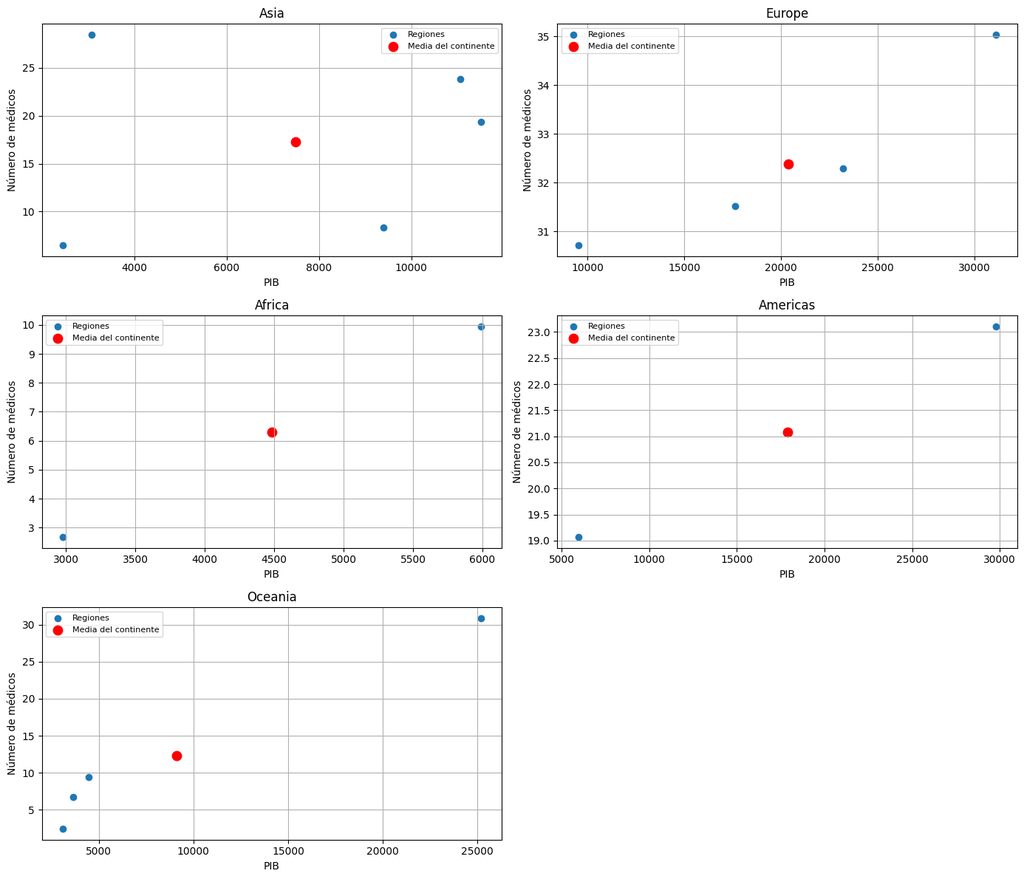

```python
import pandas as pd
import matplotlib.pyplot as plt

# Cargar los datos
paises = pd.read_csv('paises.csv')
medicos = pd.read_csv('medicos.csv')

# Renombrar columnas del fichero de médicos
medicos = medicos.rename(columns={
    'Location': 'pais',
    'First Tooltip': 'medicos'
})

# Unión interna
datos = pd.merge(
    paises,
    medicos,
    on='pais',
    how='inner'
)

# Obtener lista de continentes
continentes = datos['continente'].unique()

# Crear la figura con 3 filas y 2 columnas de subplots
fig, axes = plt.subplots(3, 2, figsize=(14, 12))
axes = axes.flatten()  # Facilita recorrerlos en un bucle

# Recorrer cada continente y su subplot
for i, continente in enumerate(continentes):
    ax = axes[i]

    # Filtrar datos del continente
    datos_cont = datos[datos['continente'] == continente]

    # Agrupar por región
    datos_region = (
        datos_cont
        .groupby('region', as_index=False)
        .agg({
            'PIB': 'mean',
            'medicos': 'mean'
        })
    )

    # Calcular medias del continente
    media_pib = datos_region['PIB'].mean()
    media_medicos = datos_region['medicos'].mean()

    # Nube de puntos
    ax.scatter(
        datos_region['PIB'],
        datos_region['medicos'],
        label='Regiones'
    )

    # Punto medio del continente
    ax.scatter(
        media_pib,
        media_medicos,
        color='red',
        s=80,
        label='Media del continente'
    )

    # Título y etiquetas
    ax.set_title(continente)
    ax.set_xlabel('PIB')
    ax.set_ylabel('Número de médicos')

    # Rejilla y leyenda
    ax.grid(True)
    ax.legend(fontsize=8)

# Elimina subplots vacíos si hay menos de 6 continentes
for j in range(i + 1, len(axes)):
    fig.delaxes(axes[j])

# Ajustar espaciado
plt.tight_layout()
plt.show()
```

# Gráfica 6.

A partir de la unión de ambos csv, redondea la cantidad de médicos al valor entero más cercano y haz un histograma para relacionar la cantidad de médicos en el eje X y la frecuencia/cantidad de países con esos médicos en el eje Y.

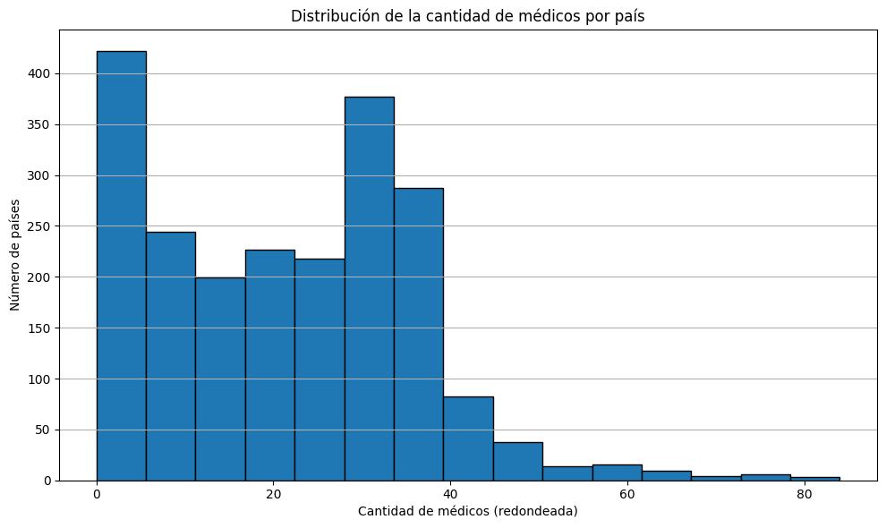

```python
import pandas as pd
import matplotlib.pyplot as plt

# Cargar los datos
paises = pd.read_csv('paises.csv')
medicos = pd.read_csv('medicos.csv')

# Renombrar columnas del fichero de médicos
medicos = medicos.rename(columns={
    'Location': 'pais',
    'First Tooltip': 'medicos'
})

# Unión interna entre ambos CSV
datos = pd.merge(
    paises,
    medicos,
    on='pais',
    how='inner'
)

# Redondear la cantidad de médicos al entero más cercano
# round() redondea al entero más próximo
datos['medicos_redondeados'] = datos['medicos'].round().astype(int)

# Crear el histograma
plt.figure(figsize=(10, 6))

plt.hist(
    datos['medicos_redondeados'],  # Datos del eje X
    bins=15,                       # Número de intervalos del histograma
    edgecolor='black'              # Bordes para distinguir mejor las barras
)

# Títulos y etiquetas
plt.title('Distribución de la cantidad de médicos por país')
plt.xlabel('Cantidad de médicos (redondeada)')
plt.ylabel('Número de países')

# Rejilla para facilitar la lectura
plt.grid(axis='y')

plt.tight_layout()
plt.show()
```

# Gráfica 7.

Haz lo mismo que la gráfica 1 pero con 4 paises en el mismo gráfico, cada país un colo diferente. España, Alemania, Francia, Italia.

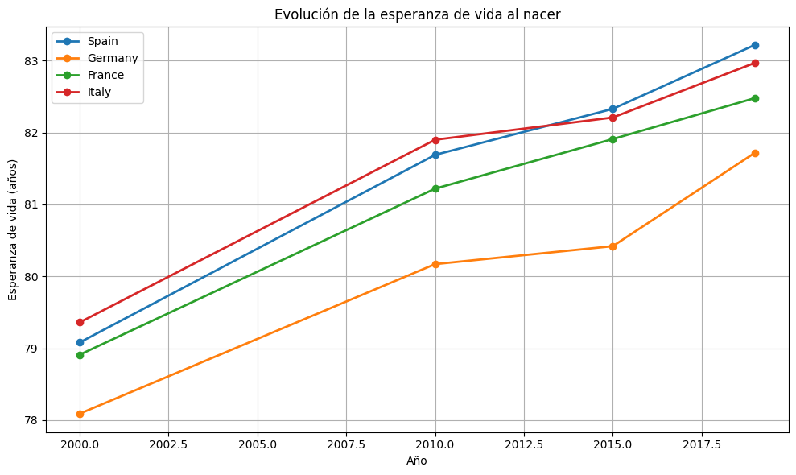

```python
import pandas as pd
import matplotlib.pyplot as plt

# Cargar los datos del CSV
data = pd.read_csv('lifeExpectancyAtBirth.csv')

# Lista de países a representar
paises = ['Spain', 'Germany', 'France', 'Italy']

# Crear la figura
plt.figure(figsize=(10, 6))

# Dibujar una línea por cada país
for pais in paises:
    datos_pais = data[(data['Location'] == pais) & (data['Dim1'] == 'Both sexes')]

    plt.plot(
        datos_pais['Period'],           # Eje X: año
        datos_pais['First Tooltip'],    # Eje Y: esperanza de vida
        marker='o',                     # Marca en cada punto
        linewidth=2,                    # Grosor de línea
        label=pais                      # Etiqueta para la leyenda
    )

# Títulos y etiquetas
plt.title('Evolución de la esperanza de vida al nacer')
plt.xlabel('Año')
plt.ylabel('Esperanza de vida (años)')

# Mostrar leyenda y rejilla
plt.legend()
plt.grid(True)

# Ajustar márgenes
plt.tight_layout()
plt.show()
```